# STAT 415 Lab 7: Comparing Two Proportions

# 5 Deriving the posterior distribution

Recall the prior distribution

- $\theta_1$ and $\theta_2$ are independent according to the prior
- $\theta_1$ has a Beta(3, 2) prior distribution
- $\theta_2$ has a Beta(3, 2) prior distribution

**PAUSE** to carefully write an expression for the prior distribution.

The prior distribution for $\theta_1$ satisfies
$$\pi(\theta_1) \propto \theta_1^{3 - 1}(1-\theta_1)^{2-1}$$
The prior distribution for $\theta_2$ satisfies
$$\pi(\theta_2) \propto \theta_2^{3 - 1}(1-\theta_2)^{2-1}$$
Since the prior assumes $\theta_1$ and $\theta_2$ are independent, the joint prior distribution for $\theta_1$ and $\theta_2$ satisfies
$$\pi(\theta_1, \theta_2) = \pi(\theta_1)\pi(\theta_2) \propto \left(\theta_1^{3 - 1}(1-\theta_1)^{2-1} \right)\left(\theta_2^{3 - 1}(1-\theta_2)^{2-1} \right)$$

Recall the sample data

- Of the 50 penguins without metal bands, 31 survived this 4.5-year study period.
- Of the 50 penguins with metal bands, 16 survived the 4.5-year study period.

**PAUSE** to carefully write the likelihood function. Is it reasonable to assume that the two samples (50 without bands, 50 with bands) are independent?

For the penguins without bands, the likelihood of 31 out of 50 penguins surviving is, from a Binomial likelihood,
$$f(y_1 = 31 | \theta_1) \propto \theta_1^{31}(1-\theta_1)^{50-31}$$

For the penguins with bands, the likelihood of 16 out of 50 penguins surviving is, from a Binomial likelihood,
$$f(y_2 = 16 | \theta_2) \propto \theta_2^{16}(1-\theta_2)^{50-16}$$

Because the penguins were randomly assigned to band/no band, it is reasonable to assume that these are two independent random samples (conditional on $\theta_1, \theta_2$). Therefore, the likelihood of the sample is the product of the two likelihoods above
$$f(y_1 = 31, y_2 = 16 | \theta_1, \theta_2) \propto \left(\theta_1^{31}(1-\theta_1)^{50-31}\right)\left(\theta_2^{16}(1-\theta_2)^{50-16}\right)$$

**PAUSE** to carefully write an expression for the posterior distribution. What do you notice? Are $\theta_1$ and $\theta_2$ independent according to the posterior distribution? What is the marginal posterior distribution of $\theta_1$? Of $\theta_2$?

Posterior is proportional to the product of prior and likelihood

$$\begin{align*}
& \quad \pi(\theta_1, \theta_2 | y_1 = 31, y_2 = 16)\\
\propto & \quad \pi(\theta_1, \theta_2) f(y_1 = 31, y_2 = 16|\theta_1, \theta_2)\\
\propto & \quad \left[\left(\theta_1^{3 - 1}(1-\theta_1)^{2-1} \right)\left(\theta_2^{3 - 1}(1-\theta_2)^{2-1} \right)\right]\left[\left(\theta_1^{31}(1-\theta_1)^{50-31}\right)\left(\theta_2^{16}(1-\theta_2)^{50-16}\right)\right]\\
\propto & \quad \left(\theta_1^{3 + 31 - 1}(1-\theta_1)^{2 + 50 - 31 -1} \right)\left(\theta_2^{3 + 16 - 1}(1-\theta_2)^{2 + 50 - 16 -1} \right)
\end{align*}$$

- Since the joint posterior distribution factors into two factors, one involving $\theta_1$ only and one involving $\theta_2$ only, then $\theta_1$ and $\theta_2$ are independent according to the posterior
- The marginal posterior distribution of $\theta_1$ is Beta(3 + 31, 2 + 19). That is, the posterior distribution of $\theta_1$ is updated based on the data from sample 1 (no band) only as in the Beta-Binomial model.
- The marginal posterior distribution of $\theta_2$ is Beta(3 + 16, 2 + 34). That is, the posterior distribution of $\theta_2$ is updated based on the data from sample 2 (band) only as in the Beta-Binomial model.

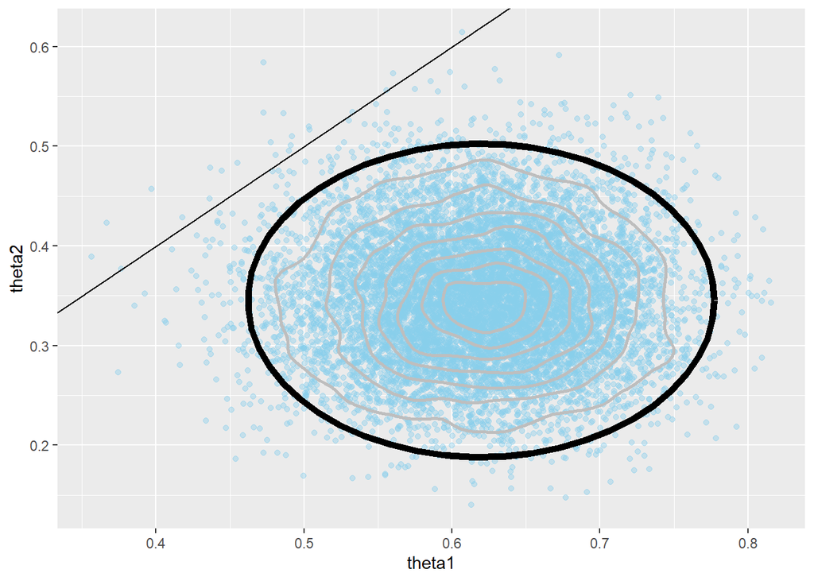

```r
# data
n1 = 50
y1 = 31

n2 = 50
y2 = 16

# posterior
alpha1 = alpha1_prior + y1
beta1 = beta1_prior + n1 - y1

alpha2 = alpha2_prior + y2
beta2 = beta2_prior + n2 - y2

theta1 = rbeta(N, alpha1, beta1)
theta2 = rbeta(N, alpha2, beta2)

sim_posterior = data.frame(theta1, theta2)

# plots
ggplot(sim_posterior, aes(theta1, theta2)) +
  geom_point(color = "skyblue", alpha = 0.4) +
  stat_ellipse(level = 0.98, color = "black", size = 2) +
  stat_density_2d(color = "grey", size = 1) +
  geom_abline(intercept = 0, slope = 1)
```

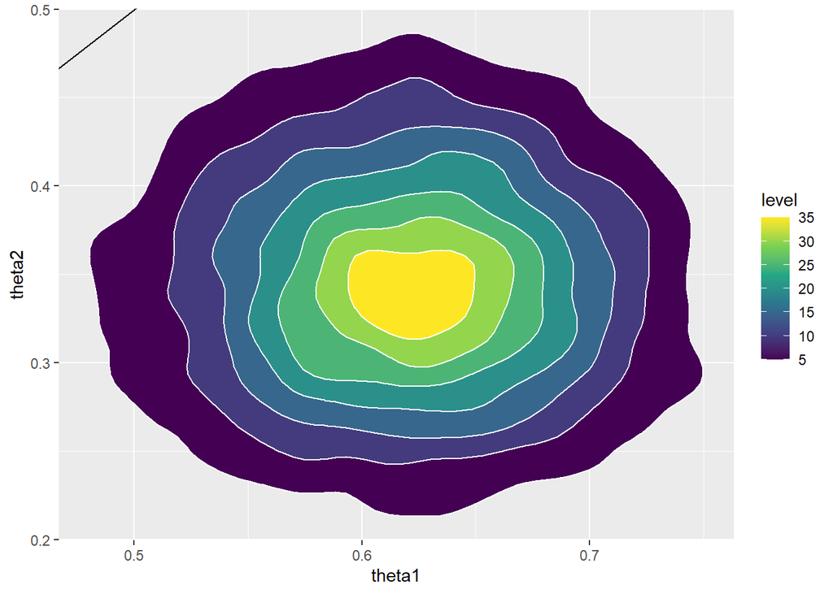

```r
ggplot(sim_posterior, aes(theta1, theta2)) +
  stat_density_2d(aes(fill = ..level..),
                  geom = "polygon", color = "white") +
  scale_fill_viridis_c() +
  geom_abline(intercept = 0, slope = 1)
```